# End2End ML Project

[figure not shown]

به نام خدا

یادگیری ماشین

### فهرست مطالب

- مقدمه و داده‌ی مورد استفاده
- نصب و راه‌اندازی
- بارگیری داده‌ها
- مصورسازی داده‌ها
- آماده‌سازی داده‌ها برای الگوریتم‌های یادگیری ماشین
- انتخاب یک مدل و نحوه‌ی آموزش آن
- یافتن مدل مناسب

مقدمه و داده‌ی مورد استفاده

هدف این متن آموزش اصول کلی یادگیری ماشین و نحوه انجام یک پروژه یادگیری ماشین از ابتدا تا انتهای آن می‌باشد در این بخش ما از مجموعه‌ی داده‌ی(Dataset) قیمت‌ خانه‌های کالیفرنیا (California Housing Prices dataset) از مخزن StatLib استفاده می‌کنیم. برای مقاصد آموزشی، یک ویژگی دسته‌ای به این مجموعه‌ی داده اضافه کرده‌ایم و چند ویژگی حذف شده‌اند.

در مرحله‌ی اول باید یک مدل از قیمت خانه‌های کالیفرنیا، با استفاده از این مجموعه‌ی داده، بسازیم. این مجموعه‌ی داده حاوی مقادیرِ جمعیت، میانه‌ی درآمد، میانه‌ی قیمت خانه و … برای هر منطقه از کالیفرنیا است.  
مدل شما باید با داده آموزش ببیند و باید بتواند با داشتن تمام مقادیر دیگر، میانه‌ی قیمت خانه در هر منطقه را پیش‌بینی کند.

نصب و راه‌اندازی

برای استفاده از کدهای این دفترچه شما نیاز دارید که پایتون 2 یا 3 را روی سیستم خود نصب کرده باشید. همچین از کتاب‌خانه های Numpy و Pandas و Scikit-learn در این پروژه استفاده خواهد شد. این سه کتاب‌خانه اصلی‌ترین کتاب‌خانه‌ها برای کارهای یادگیری ماشین در زبان پایتون می‌باشند. برای رسم نمودارها نیز از کتاب‌خانه Matplotlib استفاده می‌شود. برای دنبال کردن بهتر این دفترچه، بهتر است که اصول مقدماتی برنامه‌نویسی در زبان پایتون را بلد باشید اما نیاز به دانش خاصی در حوزه یادگیری ماشین ندارید زیرا سعی شده است همه چیز به ساده‌ترین شکل توضیح داده شود.

```python
!pip install numpy
!pip install matplotlib
!pip install pandas
!pip install scikit-learn
```

در تکه کد زیر کتاب‌خانه numpy را اضافه کرده‌ایم و seed تصادفی آن را تنظیم کرده‌ایم. دقت کنید که مشخص کردن seed در ابتدای کد نقش مهمی در reproducibility نتایج تولید شده توسط کد شما دارد. تعداد زیادی از الگوریتم‌های یادگیری ماشین از مقادیر تصادفی برای مقداردهیِ اولیه استفاده می‌کنند بنابراین اگر seed را در ابتدای کد مشخص نکرده باشید در هر بار از اجرای کدتان نتیجه‌ی متفاوتی را به دست خواهید آورد.  
در ادامه کتاب‌خانه Matplotlib اضافه شده است و حالت آن به inline تغییر کرده است. در صورتی که بخواهید نمودارهایی که رسم میکنید داخل Jupyter Notebook نمایش داده شوند باید این خط را به کد خودتان اضافه کنید. تنظیمات دیگر برای مشخص کردن سایز متن‌های داخل نمودار است. برای ذخیره‌سازی نمودارها نیز یک تابع نوشته شده است. این تابع یک پارامتر به نام $\tt{tight\_layout}$ دارد. در تصاویر زیر می‌توانید فرق نمودارهایی که با اضافه کردن این ویژگی و بدون آن رسم شده‌اند را ببینید. استفاده از این ویژگی هنگامی که می‌خواهید چند نمودار را در قالب یک تصویر نشان دهید، عادت خوبی است!

[figure not shown]

```python
# To support both python 2 and python 3
from __future__ import division, print_function, unicode_literals

# Common imports
import numpy as np
import os

# to make this notebook's output stable across runs
np.random.seed(42)

# To plot pretty figures
%matplotlib inline
import matplotlib as mpl
import matplotlib.pyplot as plt
mpl.rc('axes', labelsize=14)
mpl.rc('xtick', labelsize=12)
mpl.rc('ytick', labelsize=12)

# Where to save the figures
PROJECT_ROOT_DIR = "./"
IMAGES_PATH = os.path.join(PROJECT_ROOT_DIR, "figs/")

def save_fig(fig_id, tight_layout=True, fig_extension="png", resolution=300):
    path = os.path.join(IMAGES_PATH, fig_id + "." + fig_extension)
    print("Saving figure", fig_id)
    if tight_layout:
        plt.tight_layout()
    plt.savefig(path, format=fig_extension, dpi=resolution)

# Ignore useless warnings (see SciPy issue #5998)
import warnings
warnings.filterwarnings(action="ignore", message="^internal gelsd")
```

بارگیری (download) داده‌ها

تکه کد زیر داده‌ها را از اینترنت بارگیری می‌کند و آن را در پوشه‌ی dataset در کنار کد شما قرار می‌دهد و همچنین داده بارگیری شده را از حالت فشرده خارج می‌کند.

```python
import os
import tarfile
from six.moves import urllib

DOWNLOAD_ROOT = "https://raw.githubusercontent.com/ageron/handson-ml/master/"
HOUSING_PATH = os.path.join(PROJECT_ROOT_DIR, "datasets", "housing")
HOUSING_URL = DOWNLOAD_ROOT + "datasets/housing/housing.tgz"


def fetch_housing_data(housing_url=HOUSING_URL, housing_path=HOUSING_PATH):
    if not os.path.isdir(housing_path):
        os.makedirs(housing_path)
    tgz_path = os.path.join(housing_path, "housing.tgz")
    urllib.request.urlretrieve(housing_url, tgz_path)
    housing_tgz = tarfile.open(tgz_path)
    housing_tgz.extractall(path=housing_path)
    housing_tgz.close()


fetch_housing_data()
```

بار کردن (load) و کار با داده‌ها

ما از کتاب‌خانه Pandas برای بار کردن داده‌ها استفاده می‌کنیم. تکه کد زیر مجموعه‌ی داده‌ی بارگیری شده را که به صورت یک فایل با پسوند csv می‌باشد می‌خواند و و خروجی آن یک شیء از نوع $\texttt{Pandas.DataFrame}$ است. دیتافریم کتابخانه Pandas قابلیت‌های زیادی را در اختیار ما قرار می‌دهد که در ادامه با برخی از آنها آشنا می‌شویم.

```python
import pandas as pd


def load_housing_data(housing_path=HOUSING_PATH):
    csv_path = os.path.join(housing_path, "housing.csv")
    return pd.read_csv(csv_path)
```

پس از فراخوانی تابع، با استفاده از تابع head پنچ سطر اول از جدول داده‌ها را مشاهده می‌کنیم.

```python
housing = load_housing_data()
housing.head()
```

|  | longitude | latitude | housing_median_age | total_rooms | total_bedrooms | population | households | median_income | median_house_value | ocean_proximity |
| --- | --- | --- | --- | --- | --- | --- | --- | --- | --- | --- |
| 0 | -122.23 | 37.88 | 41.0 | 880.0 | 129.0 | 322.0 | 126.0 | 8.3252 | 452600.0 | NEAR BAY |
| 1 | -122.22 | 37.86 | 21.0 | 7099.0 | 1106.0 | 2401.0 | 1138.0 | 8.3014 | 358500.0 | NEAR BAY |
| 2 | -122.24 | 37.85 | 52.0 | 1467.0 | 190.0 | 496.0 | 177.0 | 7.2574 | 352100.0 | NEAR BAY |
| 3 | -122.25 | 37.85 | 52.0 | 1274.0 | 235.0 | 558.0 | 219.0 | 5.6431 | 341300.0 | NEAR BAY |
| 4 | -122.25 | 37.85 | 52.0 | 1627.0 | 280.0 | 565.0 | 259.0 | 3.8462 | 342200.0 | NEAR BAY |

همچنین با استفاده از تابع info می‌توان به اطلاعات کلی از قبیل تعداد سطر‌ها و ستون‌ها و ویژگی‌های هر ستون پی برد.

```python
housing.info()
```

```
<class 'pandas.core.frame.DataFrame'>
RangeIndex: 20640 entries, 0 to 20639
Data columns (total 10 columns):
longitude             20640 non-null float64
latitude              20640 non-null float64
housing_median_age    20640 non-null float64
total_rooms           20640 non-null float64
total_bedrooms        20433 non-null float64
population            20640 non-null float64
households            20640 non-null float64
median_income         20640 non-null float64
median_house_value    20640 non-null float64
ocean_proximity       20640 non-null object
dtypes: float64(9), object(1)
memory usage: 1.6+ MB
```

با دانستن نام ستون می‌توان فقط آن ستون دلخواه را از کل داده‌ها انتخاب کرده و به کمک تابع $\tt{value\_counts}$ درباره مقادیر ممکن برای آن و تعداد تکرار هر کدام از آنها اطلاع پیدا کرد.

```python
housing["ocean_proximity"].value_counts()
```

```
<1H OCEAN     9136
INLAND        6551
NEAR OCEAN    2658
NEAR BAY      2290
ISLAND           5
Name: ocean_proximity, dtype: int64
```

با فراخوانی تابع $\tt{describe}$ آماره‌های مفیدی مانند میانگین و انحراف معیار و میانه و ... روی ستون‌های مختلف محاسبه خواهد‌شد.

```python
housing.describe()
```

|  | longitude | latitude | housing_median_age | total_rooms | total_bedrooms | population | households | median_income | median_house_value |
| --- | --- | --- | --- | --- | --- | --- | --- | --- | --- |
| count | 20640.000000 | 20640.000000 | 20640.000000 | 20640.000000 | 20433.000000 | 20640.000000 | 20640.000000 | 20640.000000 | 20640.000000 |
| mean | -119.569704 | 35.631861 | 28.639486 | 2635.763081 | 537.870553 | 1425.476744 | 499.539680 | 3.870671 | 206855.816909 |
| std | 2.003532 | 2.135952 | 12.585558 | 2181.615252 | 421.385070 | 1132.462122 | 382.329753 | 1.899822 | 115395.615874 |
| min | -124.350000 | 32.540000 | 1.000000 | 2.000000 | 1.000000 | 3.000000 | 1.000000 | 0.499900 | 14999.000000 |
| 25% | -121.800000 | 33.930000 | 18.000000 | 1447.750000 | 296.000000 | 787.000000 | 280.000000 | 2.563400 | 119600.000000 |
| 50% | -118.490000 | 34.260000 | 29.000000 | 2127.000000 | 435.000000 | 1166.000000 | 409.000000 | 3.534800 | 179700.000000 |
| 75% | -118.010000 | 37.710000 | 37.000000 | 3148.000000 | 647.000000 | 1725.000000 | 605.000000 | 4.743250 | 264725.000000 |
| max | -114.310000 | 41.950000 | 52.000000 | 39320.000000 | 6445.000000 | 35682.000000 | 6082.000000 | 15.000100 | 500001.000000 |

هر Dataframe ای تابعی به نام $\tt{hist}$ دارد که با گرفتن پارامتر‌هایی مانند تعداد bin و ... نمودار هیستوگرام هر یک از ستون‌ها را رسم می‌کند. این نمودا با استفاده از تابع $\tt{save\_fig}$ که در ابتدا تعریف شد، ذخیره می‌شوند.

```
Saving figure attribute_histogram_plots
```

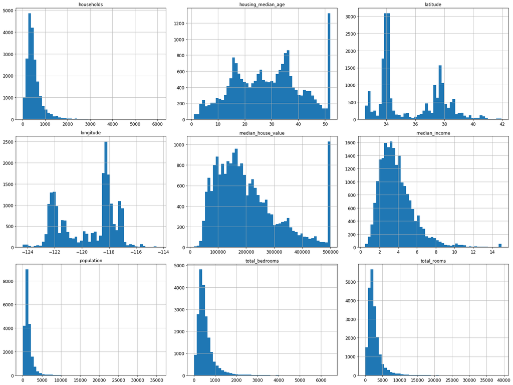

```python
%matplotlib inline
import matplotlib.pyplot as plt
housing.hist(bins=50, figsize=(20,15))
save_fig("attribute_histogram_plots")
plt.show()
```

یکی از مهم‌ترین مفاهیم در یادگیری ماشین مفهوم Generalization است. ما برای آموزش دادن مدل خود از یک مجموعه داده استفاده میکنیم که Train Set ما است. اما ما برای ارزیابی مدل خود نمی‌توانیم از Train Set استفاده کنیم زیرا مدل ما قبلا این داده‌ها را دیده است و به آن ها برازش شده است. بنابراین عمل‌کرد مدلی که با Train Set آموزش دیده شده است روی داده‌هایی که تا به حال آن‌ها را ندیده است با احتمال خوبی بدتر از عمل‌کردش روی Train Set خواهد بود. به این پدیده که مدل ما عملکرد خوبی روی داده‌های آموزش دارد اما روی داده‌های جدید عمل‌کرد بدتری دارد بیش‌برازش یا Overfitting می‌گویند.(مثل دانش‌آموزی که درسهای خود را مفهومی نمی‌خواند و آن‌ها را حفظ می‌کند و به هنگام روربرو شدن با مساله‌ی جدید، ناتوان می‌شود :دی)  
بنابراین اگر ما بخواهیم متوجه شویم که مدل ما روی داده هایی که تا به حال با آن ها روبرو نشده است چه عمل‌کردی دارد باید از قبل یک قسمت از داده‌هایمان را جدا کرده باشیم و فرآیند آموزش مدل را فقط با باقی داده‌ها انجام دهیم. بنابراین ما داده‌هایمان را به دو قسمت Train Set و Test Set تقسیم میکنیم. برای اینکه Test Set نمایان‌گر داده ای باشد که مدل ما تا به حال با آن روبرو نشده است باید به اصطلاح بعد از جداکردن Test Set آن را در یک گاوصندوق قرار دهیم و تا مشخص نشدن مدل نهایی ارزیابی نهایی را روی این مجموعه انجام ندهیم!  
با استفاده از تابع $\tt{train\_test\_split}$ که در کتابخانه sklearn قرار دارد می‌توانیم داده‌هایمان را به دو مجموعه مجزای Train و Test تفکیک کنیم. ورودی $\tt{test\_size}$ در این تابع مشخص می‌کند که چه کسری از داده‌ها به عنوان داده تست در نظر گرفته شود. این تابع داده‌ها را به صورت تصادفی به دو مجموعه Train و Test تقسیم می‌کند. برای اینکه خروجی تابع در دفعات مختلف اجرا یکسان باقی بماند باید $\tt{random\_state}$ را به عنوان ورودی تابع مشخص کنیم.

```python
from sklearn.model_selection import train_test_split

train_set, test_set = train_test_split(housing, test_size=0.2, random_state=42)
```

در زیر 5 سطر اول داده‌های تست را می‌بینیم. مشاهده می‌کنیم که اندیس سطرها دیگر به ترتیب نیست و به صورت تصادفی است.

```python
test_set.head()
```

|  | longitude | latitude | housing_median_age | total_rooms | total_bedrooms | population | households | median_income | median_house_value | ocean_proximity |
| --- | --- | --- | --- | --- | --- | --- | --- | --- | --- | --- |
| 20046 | -119.01 | 36.06 | 25.0 | 1505.0 | NaN | 1392.0 | 359.0 | 1.6812 | 47700.0 | INLAND |
| 3024 | -119.46 | 35.14 | 30.0 | 2943.0 | NaN | 1565.0 | 584.0 | 2.5313 | 45800.0 | INLAND |
| 15663 | -122.44 | 37.80 | 52.0 | 3830.0 | NaN | 1310.0 | 963.0 | 3.4801 | 500001.0 | NEAR BAY |
| 20484 | -118.72 | 34.28 | 17.0 | 3051.0 | NaN | 1705.0 | 495.0 | 5.7376 | 218600.0 | <1H OCEAN |
| 9814 | -121.93 | 36.62 | 34.0 | 2351.0 | NaN | 1063.0 | 428.0 | 3.7250 | 278000.0 | NEAR OCEAN |

فرض کنید که از دانش پیشین خود می‌دانیم که ویژگی $\tt{median\_income}$ ویژگی بسیار مهمی برای پیش بینی میانه قیمت خانه ها در هر ناحیه است. بنابراین میخواهیم که این ویژگی در داده های Train و Test به صورت متعادل تقسیم شده باشد.

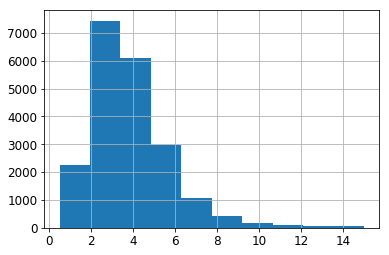

```python
housing["median_income"].hist()
```

فرض کنید در یک مسئله ویژگی مشخصی که می‌خواهیم به صورت متعادل بین مجموعه Train و Test تقسیم شود، ویژگی جنسیت افراد باشد. در این صورت کافی است درصد تعداد مردان و زنان در مجموعه‌های Train و Test یکسان باشد. اما ویژگی $\tt{median\_income}$ یک ویژگی با مقادیر پیوسته است. بنابراین برای این که بتوانیم به صورت متعادل این ویژگی را بین مجموعه‌های Trainو Test تقسیم کنیم ابتدا یک ویژگی گسسته به نام $\tt{income\_cat}$ از روی این ویژگی می‌سازیم و سپس با استفاده از آن مجموعه Train و Test را درست می‌کنیم. ویژگی $\tt{income\_cat}$ مقادیر بین 1 تا 5 را اختیار می‌کند.

```python
# Divide by 1.5 to limit the number of income categories
housing["income_cat"] = np.ceil(housing["median_income"] / 1.5)
# Label those above 5 as 5
housing["income_cat"].where(housing["income_cat"] < 5, 5.0, inplace=True)
housing["income_cat"].value_counts()
```

```
3.0    7236
2.0    6581
4.0    3639
5.0    2362
1.0     822
Name: income_cat, dtype: int64
```

درصد تکرار هر کدام از این مقادیر در مجموعه‌ی تمام داده‌ها در زیر آمده است.

```python
housing["income_cat"].value_counts() / len(housing)
```

```
3.0    0.350581
2.0    0.318847
4.0    0.176308
5.0    0.114438
1.0    0.039826
Name: income_cat, dtype: float64
```

با مشخص کردن ورودی $\tt{stratify}$ در تابع $\tt{train\_test\_split}$ میتوانیم ویژگی ای را مشخص کنیم که به صورت متعادل بین Train و Test تقسیم شوند. در زیر برای هر دو حالت (تقسیم متعادل و تقسیم معمولی) می‌توانیم درصد تکرار هر کدام از مقادیر ۱ تا ۵ را در داده تست مشاهده کنیم. می‌بینیم که در حالتی که از $\tt{stratify}$ استفاده کرده باشیم درصد هر یک از ویژگی‌ها در مجموعه Test به درصد هرکدام از ویژگی‌ها در مجموعه داده‌های اولیه نزدیک‌تر است.

```python
train_set, test_set = train_test_split(housing, test_size=0.2, random_state=42)
strat_train_set, strat_test_set = train_test_split(housing, test_size=0.2, random_state=42, stratify=housing['income_cat'])
```

```python
test_set["income_cat"].value_counts() / len(test_set)
```

```
3.0    0.358527
2.0    0.324370
4.0    0.167393
5.0    0.109496
1.0    0.040213
Name: income_cat, dtype: float64
```

```python
strat_test_set["income_cat"].value_counts() / len(strat_test_set)
```

```
3.0    0.350533
2.0    0.318798
4.0    0.176357
5.0    0.114583
1.0    0.039729
Name: income_cat, dtype: float64
```

حال می‌توانیم ستون $\tt{income\_cat}$ را که به صورت موقتی به داده‌ها اضافه کرده‌ایم را حذف کنیم.

```python
strat_train_set.drop("income_cat", axis=1, inplace=True)
strat_test_set.drop("income_cat", axis=1, inplace=True)
```

مصورسازی داده‌ها

در این قسمت با رسم نمودارهایی، اطلاعات کلی‌تری راجع به ساختار داده‌هایی که داریم به دست می‌آوریم. از این پس فقط با داده‌های Train ای که در قسمت قبل از داده‌های اصلی جدا کرده‌ایم کار می‌کنیم و دیگر به داده‌های Test دست نمی‌زنیم.

```python
housing = strat_train_set.copy()
```

با فراخوانی تابع plot روی یک Dataframe میتوانیم یکی از ویژگی‌ها را بر حسب دیگری رسم کنیم.

```
Saving figure bad_visualization_plot
```

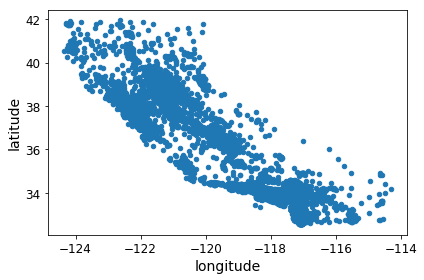

```python
housing.plot(kind="scatter", x="longitude", y="latitude")
save_fig("bad_visualization_plot")
```

برای اینکه شهود بهتری از نحوه توزیع داده‌ها به دست بیاوریم می‌توانیم ورودی $\tt{alpha}$ را تنظیم کنیم تا جاهایی که داده های بیشتری وجود دارد پررنگ‌تر رسم شوند و بقیه جاها کمرنگ‌تر. این نمودار نحوه توزیع خانه‌ها را در طول و عرض‌های جغرافیایی مختلف نشان می‌دهد.

```
Saving figure better_visualization_plot
```

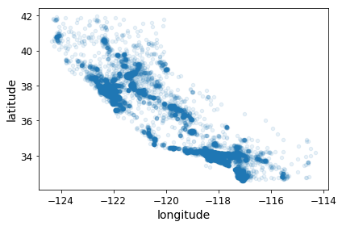

```python
housing.plot(kind="scatter", x="longitude", y="latitude", alpha=0.1)
save_fig("better_visualization_plot")
```

حال می‌خواهیم جمعیت ساکن هر منطقه و همچنین میانه‌ی قیمت خانه‌های هر منطقه را نیز به نموداری که در قسمت قبل رسم کردیم اضافه کنیم. برای اینکار سایز هرکدام از نقاطی که در نمودار رسم می‌کنیم را متناسب با ویژگی $\tt{population}$ در نظر می‌گیریم و رنگ آن را متناسب با $\tt{median\_house\_value}$ در نظر می‌گیریم. تکه کد پایین این نمودار را تولید می‌کند.

```
Saving figure housing_prices_scatterplot
```

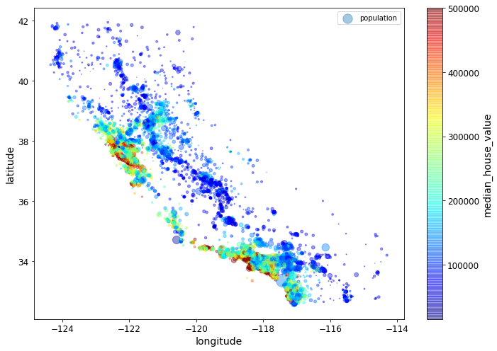

```python
housing.plot(kind="scatter", x="longitude", y="latitude", alpha=0.4,
    s=housing["population"]/100, label="population", figsize=(10,7),
    c="median_house_value", cmap=plt.get_cmap("jet"), colorbar=True,
    sharex=False) # s is size and c is color
plt.legend()
save_fig("housing_prices_scatterplot")
```

حال با اضافه کردن نقشه جغرافیایی کالیفرنیا در کنار نقشه بالا متوجه می‌شویم که ناحیه‌هایی که به دریا نزدیک‌تر هستند جمعیت ساکن بیشتری دارند و قیمت آن خانه‌ها نیز بیشتر است.

```
Saving figure california_housing_prices_plot
```

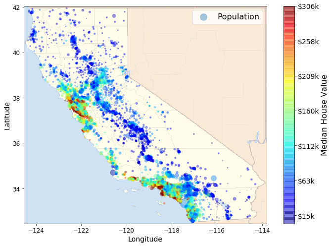

```python
import matplotlib.image as mpimg
california_img=mpimg.imread(PROJECT_ROOT_DIR + '/figs/california.png')
ax = housing.plot(kind="scatter", x="longitude", y="latitude", figsize=(10,7),
                       s=housing['population']/100, label="Population",
                       c="median_house_value", cmap=plt.get_cmap("jet"),
                       colorbar=False, alpha=0.4,
                      )
plt.imshow(california_img, extent=[-124.55, -113.80, 32.45, 42.05], alpha=0.5,
           cmap=plt.get_cmap("jet"))
plt.ylabel("Latitude", fontsize=14)
plt.xlabel("Longitude", fontsize=14)

prices = housing["median_house_value"]
tick_values = np.linspace(prices.min(), prices.max(), 11)
cbar = plt.colorbar()
cbar.ax.set_yticklabels(["$%dk"%(round(v/1000)) for v in tick_values], fontsize=14)
cbar.set_label('Median House Value', fontsize=16)

plt.legend(fontsize=16)
save_fig("california_housing_prices_plot")
plt.show()
```

هدف پیش‌بینی $\tt{median\_house\_value}$ از روی بقیه ویژگی‌ها است. تکه کد پایین هم‌بستگی (correlation) هر کدام از ویژگی‌ها را با این ویژگی مشخص می‌کند و با استفاده از تابع $\tt{sort}$ آن‌ها را به ترتیب نزولی نمایش می‌دهد. مشاهده می‌کنیم که $\tt{median\_income}$ رابطه خطی نسبتا زیادی با $\tt{median\_house\_value}$ دارد.

```python
corr_matrix = housing.corr()
corr_matrix["median_house_value"].sort_values(ascending=False)
```

```
median_house_value    1.000000
median_income         0.687160
total_rooms           0.135097
housing_median_age    0.114110
households            0.064506
total_bedrooms        0.047689
population           -0.026920
longitude            -0.047432
latitude             -0.142724
Name: median_house_value, dtype: float64
```

با تابع $\tt{scatter\_matrix}$ می‌توانیم نمودار هر ویژگی بر حسب ویژگی دیگر را رسم کنیم. نمودارهایی که روی قطر قرار دارند هیستوگرام هریک از ویژگی‌ها است.

```
Saving figure scatter_matrix_plot
```

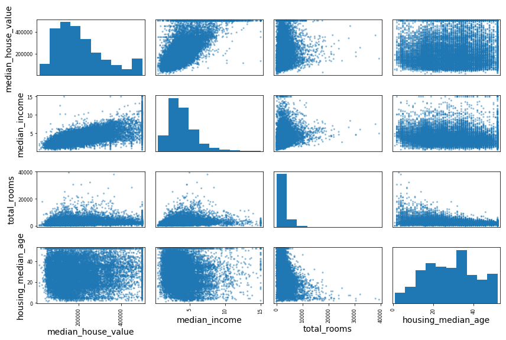

```python
# from pandas.tools.plotting import scatter_matrix # For older versions of Pandas
from pandas.plotting import scatter_matrix

attributes = ["median_house_value", "median_income", "total_rooms",
              "housing_median_age"]
scatter_matrix(housing[attributes], figsize=(12, 8))
save_fig("scatter_matrix_plot")
```

حال اگر به نمودار $\tt{median\_income}$ بر حسب $\tt{median\_house\_value}$ نگاه کنیم متوجه می‌شویم که تعداد زیادی از ناحیه‌ها هست که $\tt{median\_income}$ های متفاوتی دارند اما $\tt{median\_house\_value}$ برای آنها مقدار 500000 دارد. از روی این نمودار متوجه می‌شویم که احتمالا ستون $\tt{median\_house\_value}$ که در داده‌ها وجود داشت قبلا از بالا بریده(clip) شده است و مقادیر بیشتر از 500000 را برابر با 500000 قرار داده اند.

```
Saving figure income_vs_house_value_scatterplot
```

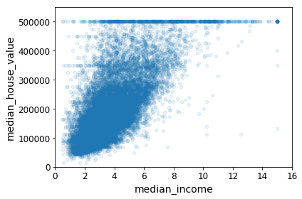

```python
housing.plot(kind="scatter", x="median_income", y="median_house_value",
             alpha=0.1)
plt.axis([0, 16, 0, 550000])
save_fig("income_vs_house_value_scatterplot")
```

احتمالا متوجه شده‌اید که ویژگی‌های $\tt{total\_rooms}$ و $\tt{population}$ و $\tt{total\_bedrooms}$ برای ناحیه‌های مختلف قابل مقایسه نیستند زیرا در هر ناحیه تعداد خانه‌های متفاوتی وجود دارد و هر چه تعداد خانه‌ها بیشتر باشد این مقادیر نیز بیشتر خواهند بود. به منظور داشتن اطلاعات مفیدتری از این ستون‌ها کد زیر ویژگی‌های $\tt{rooms\_per\_household}$ و $\tt{bedrooms\_per\_room}$ و $\tt{population\_per\_household}$ را به Dataframe اضافه می‌کند.

```python
housing["rooms_per_household"] = housing["total_rooms"]/housing["households"]
housing["bedrooms_per_room"] = housing["total_bedrooms"]/housing["total_rooms"]
housing["population_per_household"]=housing["population"]/housing["households"]
```

حال بعد از اضافه کردن این ویژگی‌ها می‌توانیم دوباره هم‌بستگی‌ها را حساب کنیم. مشاهده می‌کنیم که ویژگی $\tt{bedrooms\_per\_room}$ که اضافه کرده‌ایم رابطه خطی معکوس نسبتا زیادی با $\tt{median\_house\_value}$ دارد در حالی که $\tt{total\_bedrooms}$ تقریبا هیچ رابطه‌ای خطی با $\tt{median\_house\_value}$ ندارد. یکی از کارهایی که تاثیر زیادی در کارآیی مدل شما دارد Feature Engineering یا انتخاب کردن و تغییر دادن ویژگی‌ها به گونه‌ای است که برای مدل قابل فهم‌تر باشند. کاری که پیش از این انجام دادیم نمونه‌ای از آن است.

```python
corr_matrix = housing.corr()
corr_matrix["median_house_value"].sort_values(ascending=False)
```

```
median_house_value          1.000000
median_income               0.687160
rooms_per_household         0.146285
total_rooms                 0.135097
housing_median_age          0.114110
households                  0.064506
total_bedrooms              0.047689
population_per_household   -0.021985
population                 -0.026920
longitude                  -0.047432
latitude                   -0.142724
bedrooms_per_room          -0.259984
Name: median_house_value, dtype: float64
```

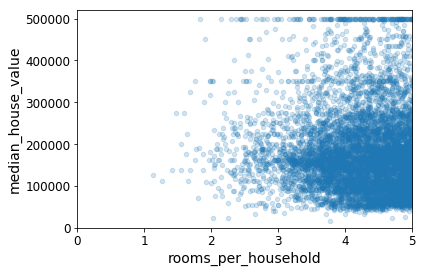

```python
housing.plot(kind="scatter", x="rooms_per_household", y="median_house_value",
             alpha=0.2)
plt.axis([0, 5, 0, 520000])
plt.show()
```

پس از تغییراتی که صورت گرفت آماره‌های کلی درباره ستون‌های مختلف را به دست می‌آوریم.

```python
housing.describe()
```

|  | longitude | latitude | housing_median_age | total_rooms | total_bedrooms | population | households | median_income | median_house_value | rooms_per_household | bedrooms_per_room | population_per_household |
| --- | --- | --- | --- | --- | --- | --- | --- | --- | --- | --- | --- | --- |
| count | 16512.000000 | 16512.000000 | 16512.000000 | 16512.000000 | 16354.000000 | 16512.000000 | 16512.000000 | 16512.000000 | 16512.000000 | 16512.000000 | 16354.000000 | 16512.000000 |
| mean | -119.575834 | 35.639577 | 28.653101 | 2622.728319 | 534.973890 | 1419.790819 | 497.060380 | 3.875589 | 206990.920724 | 5.440341 | 0.212878 | 3.096437 |
| std | 2.001860 | 2.138058 | 12.574726 | 2138.458419 | 412.699041 | 1115.686241 | 375.720845 | 1.904950 | 115703.014830 | 2.611712 | 0.057379 | 11.584826 |
| min | -124.350000 | 32.540000 | 1.000000 | 6.000000 | 2.000000 | 3.000000 | 2.000000 | 0.499900 | 14999.000000 | 1.130435 | 0.100000 | 0.692308 |
| 25% | -121.800000 | 33.940000 | 18.000000 | 1443.000000 | 295.000000 | 784.000000 | 279.000000 | 2.566775 | 119800.000000 | 4.442040 | 0.175304 | 2.431287 |
| 50% | -118.510000 | 34.260000 | 29.000000 | 2119.500000 | 433.000000 | 1164.000000 | 408.000000 | 3.540900 | 179500.000000 | 5.232284 | 0.203031 | 2.817653 |
| 75% | -118.010000 | 37.720000 | 37.000000 | 3141.000000 | 644.000000 | 1719.250000 | 602.000000 | 4.744475 | 263900.000000 | 6.056361 | 0.239831 | 3.281420 |
| max | -114.310000 | 41.950000 | 52.000000 | 39320.000000 | 6210.000000 | 35682.000000 | 5358.000000 | 15.000100 | 500001.000000 | 141.909091 | 1.000000 | 1243.333333 |

آماده‌سازی داده‌ها برای الگوریتم‌های یادگیری ماشین

حال با رسم نمودارهایی اطلاعات کلی‌تری در مورد ویژگی‌هایی که داریم به دست می‌آوریم. در این بخش برچسب داده‌ها را از داده‌ها جدا کرده و در متغیر دیگری نگه می‌داریم و روی بقیه ویژگی‌ها کار می‌کنیم.

```python
housing = strat_train_set.drop("median_house_value", axis=1) # drop labels for training set
housing_labels = strat_train_set["median_house_value"].copy()
```

بیشتر الگوریتم‌های یادگیری ماشین نمی‌توانند با ویژگی‌هایی کار کنند که در بعضی از داده‌ها جا افتاده‌اند. از این رو پیش از آن که داده‌ها به الگوریتم داده شوند، می‌بایست تغییراتی در آن‌ها صورت گیرد. برای این کار روش‌های متعددی وجود دارد که مهم‌ترین آنها در ادامه آمده است. ابتدا تعدادی از داده‌ها را که ويژگی NaN دارند بدست می‌آوریم.

```python
sample_incomplete_rows = housing[housing.isnull().any(axis=1)].head()
sample_incomplete_rows
```

|  | longitude | latitude | housing_median_age | total_rooms | total_bedrooms | population | households | median_income | ocean_proximity |
| --- | --- | --- | --- | --- | --- | --- | --- | --- | --- |
| 4629 | -118.30 | 34.07 | 18.0 | 3759.0 | NaN | 3296.0 | 1462.0 | 2.2708 | <1H OCEAN |
| 6068 | -117.86 | 34.01 | 16.0 | 4632.0 | NaN | 3038.0 | 727.0 | 5.1762 | <1H OCEAN |
| 17923 | -121.97 | 37.35 | 30.0 | 1955.0 | NaN | 999.0 | 386.0 | 4.6328 | <1H OCEAN |
| 13656 | -117.30 | 34.05 | 6.0 | 2155.0 | NaN | 1039.0 | 391.0 | 1.6675 | INLAND |
| 19252 | -122.79 | 38.48 | 7.0 | 6837.0 | NaN | 3468.0 | 1405.0 | 3.1662 | <1H OCEAN |

همان طور که دیده می‌شود ستون $\tt{total\_bedrooms}$ در مثال‌های بالا مقدار NaN دارد. در روش اول می‌توان تمام سطر‌هایی را که در یک یا چند ویژگی دلخواه مقدار مشخص ندارند، حذف کرد. پس از این کار می‌توان دید که تمام داده‌هایی که در ستون $\tt{total\_bedrooms}$ مقدار نامشخص داشتند حذف می‌شوند.

```python
sample_incomplete_rows.dropna(subset=["total_bedrooms"])    # option 1
```

|  | longitude | latitude | housing_median_age | total_rooms | total_bedrooms | population | households | median_income | ocean_proximity |
| --- | --- | --- | --- | --- | --- | --- | --- | --- | --- |

در روش دوم می‌توان کل ستون $\tt{total\_bedrooms}$ را از ویژگی‌هایی که در نظر گرفته می‌شود حذف کرد. باید توجه داشت که در بعضی موارد این کار می‌تواند موجب آن شود که ویژگی مهمی به علت مشخص نبودنش برای تعداد اندکی از داده‌ها حذف شده و فرایند یادگیری را سخت‌تر کند.

```python
sample_incomplete_rows.drop("total_bedrooms", axis=1)       # option 2
```

|  | longitude | latitude | housing_median_age | total_rooms | population | households | median_income | ocean_proximity |
| --- | --- | --- | --- | --- | --- | --- | --- | --- |
| 4629 | -118.30 | 34.07 | 18.0 | 3759.0 | 3296.0 | 1462.0 | 2.2708 | <1H OCEAN |
| 6068 | -117.86 | 34.01 | 16.0 | 4632.0 | 3038.0 | 727.0 | 5.1762 | <1H OCEAN |
| 17923 | -121.97 | 37.35 | 30.0 | 1955.0 | 999.0 | 386.0 | 4.6328 | <1H OCEAN |
| 13656 | -117.30 | 34.05 | 6.0 | 2155.0 | 1039.0 | 391.0 | 1.6675 | INLAND |
| 19252 | -122.79 | 38.48 | 7.0 | 6837.0 | 3468.0 | 1405.0 | 3.1662 | <1H OCEAN |

روش سوم که بیشتر توصیه می‌شود آن است که مقادیر گم‌شده را با استفاده از داده‌هایی که از آن ویژگی داریم پر کنیم. به عنوان مثال می‌توان میانه داده‌ها را به جای مقادیری که مشخص نیستند قرار داد.

```python
median = housing["total_bedrooms"].median()
sample_incomplete_rows["total_bedrooms"].fillna(median, inplace=True) # option 3
sample_incomplete_rows
```

|  | longitude | latitude | housing_median_age | total_rooms | total_bedrooms | population | households | median_income | ocean_proximity |
| --- | --- | --- | --- | --- | --- | --- | --- | --- | --- |
| 4629 | -118.30 | 34.07 | 18.0 | 3759.0 | 433.0 | 3296.0 | 1462.0 | 2.2708 | <1H OCEAN |
| 6068 | -117.86 | 34.01 | 16.0 | 4632.0 | 433.0 | 3038.0 | 727.0 | 5.1762 | <1H OCEAN |
| 17923 | -121.97 | 37.35 | 30.0 | 1955.0 | 433.0 | 999.0 | 386.0 | 4.6328 | <1H OCEAN |
| 13656 | -117.30 | 34.05 | 6.0 | 2155.0 | 433.0 | 1039.0 | 391.0 | 1.6675 | INLAND |
| 19252 | -122.79 | 38.48 | 7.0 | 6837.0 | 433.0 | 3468.0 | 1405.0 | 3.1662 | <1H OCEAN |

اخطار: از آنجا که از ورژن ۰.۲۰ کتابخانه Scikit-Learn به بعد sklearn.preprocessing.Imputer با sklearn.preprocessing.SimpleImupter جایگزین شده است به صورت زیر این کلاس را import می‌کنیم. در نمونه‌ای که از این کلاس می‌گیریم مشخص می‌کنیم که می‌خواهیم مقادیر گم‌شده را با استفاده از میانه جایگزین کنیم.

```python
try:
    from sklearn.impute import SimpleImputer # Scikit-Learn 0.20+
except ImportError:
    from sklearn.preprocessing import Imputer as SimpleImputer

imputer = SimpleImputer(strategy="median")
```

از آنجا که میانه تنها برای داده‌های عددی قابل محاسبه است، یک کپی از داده‌ها درست می‌کنیم که داده از نوع متن $\tt{ocean\_proximity}$ را نداشته باشد.

```python
housing_num = housing.drop('ocean_proximity', axis=1)
# alternatively: housing_num = housing.select_dtypes(include=[np.number])
```

سپس با استفاده از تابع $\tt{fit}$ و دادن مجموعه داده‌ها به عنوان ورودی، می‌توان میانه‌ها را به دست آورد که نتیجه در متغیر $\tt{statistics\underline{}}$ ذخیره شده است.

```python
imputer.fit(housing_num)
```

```
SimpleImputer(copy=True, fill_value=None, missing_values=nan,
       strategy='median', verbose=0)
```

```python
imputer.statistics_
```

```
array([-118.51  ,   34.26  ,   29.    , 2119.5   ,  433.    , 1164.    ,
        408.    ,    3.5409])
```

بررسی می‌کنیم که مقادیر محاسبه شده در بالا با مقادیری که از محاسبه‌ی مستقیم میانه‌ها به دست می‌آیند، یکی هستند یا خیر.

```python
housing_num.median().values
```

```
array([-118.51  ,   34.26  ,   29.    , 2119.5   ,  433.    , 1164.    ,
        408.    ,    3.5409])
```

حال با فراخوانی تابع $\tt{transform}$ روی imputerای که آموزش داده شده است، مقادیر گم‌شده را برای داده‌ی اولیه جایگزین می‌کنیم.

```python
X = imputer.transform(housing_num)
```

از آن جا که نتیجه اجرای این تابع یک آرایه numpy است، آن را به حالت dataframe در می‌آوریم.

```python
housing_tr = pd.DataFrame(X, columns=housing_num.columns,
                          index = list(housing.index.values))
```

حال پس از اعمال تغییرات، داده‌هایی را که مقادیر گم‌شده داشتند نمایش می‌دهیم. همان طور که در ادامه می‌بینید ستون $\tt{total\_bedrooms}$ برای همه آن‌ها با مقدار میانه، جایگزین شده است.

```python
housing_tr.loc[sample_incomplete_rows.index.values]
```

|  | longitude | latitude | housing_median_age | total_rooms | total_bedrooms | population | households | median_income |
| --- | --- | --- | --- | --- | --- | --- | --- | --- |
| 4629 | -118.30 | 34.07 | 18.0 | 3759.0 | 433.0 | 3296.0 | 1462.0 | 2.2708 |
| 6068 | -117.86 | 34.01 | 16.0 | 4632.0 | 433.0 | 3038.0 | 727.0 | 5.1762 |
| 17923 | -121.97 | 37.35 | 30.0 | 1955.0 | 433.0 | 999.0 | 386.0 | 4.6328 |
| 13656 | -117.30 | 34.05 | 6.0 | 2155.0 | 433.0 | 1039.0 | 391.0 | 1.6675 |
| 19252 | -122.79 | 38.48 | 7.0 | 6837.0 | 433.0 | 3468.0 | 1405.0 | 3.1662 |

```python
imputer.strategy
```

```
'median'
```

```python
housing_tr = pd.DataFrame(X, columns=housing_num.columns)
housing_tr.head()
```

|  | longitude | latitude | housing_median_age | total_rooms | total_bedrooms | population | households | median_income |
| --- | --- | --- | --- | --- | --- | --- | --- | --- |
| 0 | -121.89 | 37.29 | 38.0 | 1568.0 | 351.0 | 710.0 | 339.0 | 2.7042 |
| 1 | -121.93 | 37.05 | 14.0 | 679.0 | 108.0 | 306.0 | 113.0 | 6.4214 |
| 2 | -117.20 | 32.77 | 31.0 | 1952.0 | 471.0 | 936.0 | 462.0 | 2.8621 |
| 3 | -119.61 | 36.31 | 25.0 | 1847.0 | 371.0 | 1460.0 | 353.0 | 1.8839 |
| 4 | -118.59 | 34.23 | 17.0 | 6592.0 | 1525.0 | 4459.0 | 1463.0 | 3.0347 |

در ادامه می‌خواهیم با داده‌ی دسته‌ای $\tt{ocean\_proximity}$ کار کنیم. همان طور که پیش از این ذکر شد این ویژگی از نوع متن است و به همین دلیل نمی‌توان میانه‌اش را محاسبه کرد. بیشتر الگوریتم‌های یادگیری ماشین با مقادیر عددی کار می‌کنند پس بهتر است این نوع ویژگی‌ها را به عدد تبدیل کرد.

```python
housing_cat = housing[['ocean_proximity']]
housing_cat.head(10)
```

|  | ocean_proximity |
| --- | --- |
| 17606 | <1H OCEAN |
| 18632 | <1H OCEAN |
| 14650 | NEAR OCEAN |
| 3230 | INLAND |
| 3555 | <1H OCEAN |
| 19480 | INLAND |
| 8879 | <1H OCEAN |
| 13685 | INLAND |
| 4937 | <1H OCEAN |
| 4861 | <1H OCEAN |

**اخطار:** برای عددی کردن ویژگی‌های متنیِ دسته‌ای می‌توان از کلاس‌های $\tt{LabelEncoder}$ و یا تابع $\tt{Series.factorize()}$ مربوط به کتابخانه Pandas استفاده کرد. اما کلاس $\tt{OrdinalEncoder}$ که در ورژن ۰.۲۰ Scikit-Learn ارائه شده است به علت آنکه با ويژگی‌های ورودی کار می‌کند و عملکرد بهتری با Pipeline ( که در ادامه توضیح داده‌خواهد شده) دارد ارجح است. اگر ورژن قدیمی‌تری از Scikit-Learn را استفاده می‌کنید باید آن را از future_encoders.py بخوانید.

```python
try:
    from sklearn.preprocessing import OrdinalEncoder
except ImportError:
    from future_encoders import OrdinalEncoder # Scikit-Learn < 0.20
```

با فراخوانی تابع $\tt{fit\underline{}transform}$ از این کلاس، داده دسته‌ای ورودی به داده‌ی عددی کد می‌شود که ۱۰ خط اول آن را نمایش می‌دهیم. هم‌چنین با استفاده از ويژگی $\tt{categories\underline{}}$ می‌توان به رشته‌ی متنی دسته‌ها پی برد.

```python
ordinal_encoder = OrdinalEncoder()
housing_cat_encoded = ordinal_encoder.fit_transform(housing_cat)
housing_cat_encoded[:10]
```

```
array([[0.],
       [0.],
       [4.],
       [1.],
       [0.],
       [1.],
       [0.],
       [1.],
       [0.],
       [0.]])
```

```python
ordinal_encoder.categories_
```

```
[array(['<1H OCEAN', 'INLAND', 'ISLAND', 'NEAR BAY', 'NEAR OCEAN'],
       dtype=object)]
```

مشاهده می‌کنیم که به جای هر کدام از مقادیر متنی ویژگی $\tt{ocean\_proximity}$ یکی از اعداد 0 تا 4 قرار داده شده است. در واقع این نگاشت از متن به اعداد طبیعی را می‌توانستیم به ترتیب دیگری انجام دهیم؛ مثلا به جای اینکه به $\tt{INLAND}$ مقدار 1 را نسبت دهیم می‌توانستیم به آن مقدار 3 را نسبت دهیم. هم‌چنین می‌توانستیم به جای اینکه مقادیر 0, 1, 3, 4 را نسبت دهیم، از مقادیر 0, 100, 300, 1000, 50000 استفاده کنیم. برای این که این کار را انجام دهیم میتوانیم از One-hot Encoding استفاده کنیم. در این حالت مقادیر مختلفی که ویژگی های دسته‌ای می‌گیرند از یک‌دیگر مستقل خواهند شد. اگر مثلا یک ویژگی متنی داشته باشیم که 3 مقدار مختلف A, B, C را می‌گیرد آن را تبدیل به یک بردار 3 بعدی می‌کنیم به صورتی که:

A ---> [1, 0, 0]  
B ---> [0, 1, 0]  
C ---> [0, 0, 1]

```python
try:
    from sklearn.preprocessing import OrdinalEncoder # just to raise an ImportError if Scikit-Learn < 0.20
    from sklearn.preprocessing import OneHotEncoder
except ImportError:
    from future_encoders import OneHotEncoder # Scikit-Learn < 0.20

cat_encoder = OneHotEncoder(sparse=False)
housing_cat_1hot = cat_encoder.fit_transform(housing_cat)
housing_cat_1hot
```

```
array([[1., 0., 0., 0., 0.],
       [1., 0., 0., 0., 0.],
       [0., 0., 0., 0., 1.],
       ...,
       [0., 1., 0., 0., 0.],
       [1., 0., 0., 0., 0.],
       [0., 0., 0., 1., 0.]])
```

```python
cat_encoder.categories_
```

```
[array(['<1H OCEAN', 'INLAND', 'ISLAND', 'NEAR BAY', 'NEAR OCEAN'],
       dtype=object)]
```

حال می‌خواهیم مراحل مختلف پیش‌پردازشی را که روی داده‌ها انجام دادیم (پر کردن Nanها و اضافه کردن ویژگی هایی مانند $\tt{rooms\_per\_household}$ ) در قالب یک Pipeline انجام دهیم ابتدا ستون‌هایی را که مقادیرشان عددی است از ستون‌هایی که مقادیر غیرعددی دارند جدا می‌کنیم. چون که پیش‌پردازشی که روی این نوع ستون‌ها باید انجام بگیرد متفاوت است.

```python
numerical_columns = housing.columns.drop('ocean_proximity')
categorical_columns = pd.Index(['ocean_proximity'])
housing_numerical = housing[numerical_columns]
housing_categorical = housing[categorical_columns]
```

به صورت کلی عملکرد $\tt{Pipeline}$ به این صورت است که یک ورودی می‌گیرد و روی آن پردازش‌هایی انجام می‌دهد و سپس یک خروجی می‌دهد. خط‌‌لوله‌ای که ساخته‌ایم از 3 مرحله تشکیل شده است. مرحله اول $\tt{Imputer}$ است که جاهایی از داده ها را که Nan است پر می‌کند. سپس خروجی مرحله اول وارد مرحله دوم می‌شود. کلاسِ مربوط به مرحله دوم را خودمان تعریف کرده‌ایم. این کلاس ویژگی های $\tt{rooms\_per\_household}$ و ... را به داده‌هایمان اضافه می‌کند. هم‌چنین می‌توانیم به عنوان ورودی تعیین کنیم که ویژگی $\tt{bedrooms\_per\_room}$ اضافه شود یا خیر. آخرین مرحله از Pipeline که $\tt{StandardScaler}$ است مسئولیت نرمال کردن ستون‌های عددی را برعهده دارد. این تابع به صورت پیش‌فرض هر ستون را با یک تبدیل خطی به گونه‌ای تغییر می‌دهد که میانگینش صفر شود و انحراف معیار آن برابر با ۱ شود.

```python
from sklearn.base import BaseEstimator, TransformerMixin
from sklearn.pipeline import Pipeline
from sklearn.preprocessing import StandardScaler


class CombinedAttributesAdder(BaseEstimator, TransformerMixin):
    def __init__(self, add_bedrooms_per_room=False): # no *args or **kargs
        self.add_bedrooms_per_room = add_bedrooms_per_room
    def fit(self, X, y=None):
        return self  # nothing else to do
    def transform(self, X, y=None):
        X_df = pd.DataFrame(X, columns=numerical_columns)
        X_df["rooms_per_household"] = X_df["total_rooms"]/X_df["households"]
        X_df["population_per_household"]=X_df["population"]/X_df["households"]
        if self.add_bedrooms_per_room:
            X_df["bedrooms_per_room"] = X_df["total_bedrooms"]/X_df["total_rooms"]
        return X_df

numerical_pipeline = Pipeline([
        ('imputer', SimpleImputer(strategy="median")),
        ('attribs_adder', CombinedAttributesAdder(add_bedrooms_per_room=True)),
        ('std_scaler', StandardScaler()),
    ])

housing_numerical_transformed = numerical_pipeline.fit_transform(housing_numerical)
housing_numerical_transformed
```

```
array([[-1.15604281,  0.77194962,  0.74333089, ..., -0.31205452,
        -0.08649871,  0.15531753],
       [-1.17602483,  0.6596948 , -1.1653172 , ...,  0.21768338,
        -0.03353391, -0.83628902],
       [ 1.18684903, -1.34218285,  0.18664186, ..., -0.46531516,
        -0.09240499,  0.4222004 ],
       ...,
       [ 1.58648943, -0.72478134, -1.56295222, ...,  0.3469342 ,
        -0.03055414, -0.52177644],
       [ 0.78221312, -0.85106801,  0.18664186, ...,  0.02499488,
         0.06150916, -0.30340741],
       [-1.43579109,  0.99645926,  1.85670895, ..., -0.22852947,
        -0.09586294,  0.10180567]])
```

همان‌طور که مشاهده می‌کنیم میانگین ستون‌ها عددهای بسیار نزدیک به صفر و انحراف معیار ستون ها ۱ است.

```python
np.mean(housing_numerical_transformed, axis=0)
```

```
array([-4.35310702e-15,  2.28456358e-15, -4.70123509e-17,  7.58706190e-17,
        1.36061489e-16, -3.70074342e-17,  2.07897868e-17, -2.10210832e-16,
        8.01469141e-17, -1.62176474e-17, -4.87874168e-17])
```

```python
np.std(housing_numerical_transformed, axis=0)
```

```
array([1., 1., 1., 1., 1., 1., 1., 1., 1., 1., 1.])
```

حال با استفاده از کلاس $\tt{ColumnTransformer}$ می‌توانیم تبدیل‌های مختلفی روی ستون‌های مختلف داده اولیه اعمال کنیم و در نهایت با کنار هم گذاشتن ستون‌های تبدیل یافته به داده نهایی برسیم.

```python
try:
    from sklearn.compose import ColumnTransformer
except ImportError:
    from future_encoders import ColumnTransformer # Scikit-Learn < 0.20

num_attribs = list(housing_num)
cat_attribs = ["ocean_proximity"]

numerical_pipeline = Pipeline([
        ('imputer', SimpleImputer(strategy="median")),
        ('attribs_adder', CombinedAttributesAdder(add_bedrooms_per_room=True)),
        ('std_scaler', StandardScaler()),
    ])

categorical_pipeline = Pipeline([
        ('imputer', SimpleImputer(strategy="most_frequent")),
        ("onehot_encoder", OneHotEncoder())
])



full_pipeline = ColumnTransformer([
        ("num", numerical_pipeline, numerical_columns),
        ("cat", categorical_pipeline, categorical_columns),
    ])

housing_prepared = full_pipeline.fit_transform(housing)
housing_prepared
```

```
array([[-1.15604281,  0.77194962,  0.74333089, ...,  0.        ,
         0.        ,  0.        ],
       [-1.17602483,  0.6596948 , -1.1653172 , ...,  0.        ,
         0.        ,  0.        ],
       [ 1.18684903, -1.34218285,  0.18664186, ...,  0.        ,
         0.        ,  1.        ],
       ...,
       [ 1.58648943, -0.72478134, -1.56295222, ...,  0.        ,
         0.        ,  0.        ],
       [ 0.78221312, -0.85106801,  0.18664186, ...,  0.        ,
         0.        ,  0.        ],
       [-1.43579109,  0.99645926,  1.85670895, ...,  0.        ,
         1.        ,  0.        ]])
```

مشاهده می‌کنیم که داده نهایی آموزش 16512 سطر دارد و 16 ستون که ستون‌هایی از آن را چاپ می‌کنیم.

```python
housing_prepared.shape
```

```
(16512, 16)
```

```python
housing.columns
```

```
Index(['longitude', 'latitude', 'housing_median_age', 'total_rooms',
       'total_bedrooms', 'population', 'households', 'median_income',
       'ocean_proximity'],
      dtype='object')
```

انتخاب یک مدل و آموزش دادن آن

حال وقت آن است که یک مدل انتخاب کرده و آن را با استفاده از داده‌های آموزش تعلیم دهیم! به عنوان اولین مثال سعی می‌کنیم ویژگی $\tt{median\_house\_value}$ را برحسب سایر ویژگی‌ها پیش‌بینی کنیم.  
ساده ترین مدلی که برای تخمین زدن یک مقدار حقیقی بر حسب تعدادی ویژگی وجود دارد، رگرسیون خطی است. کتابخانه Scikit-learn تعداد زیادی از مدل‌های یادگیری ماشین را به صورت آماده در خود جای داده است.  
تکه کد زیر یک مدل رگرسیون خطی را تعریف می‌کند و سپس آن را به داده های آموزش می‌برازاند(!) و بعد از برازش مدل میتوانیم با استفاده از تابع $\tt{score}$ درکی از میزان نزدیک بودن مقادیر تخمینی و مقادیر واقعی به دست بیاوریم.  
برای رگرسیون خطی این امتیاز هرچقدر به 1 یا -1 نزدیک تر باشد به معنی این است که تخمین مدل به واقعیت نزدیک‌تر است.

```python
from sklearn.linear_model import LinearRegression

lin_reg = LinearRegression()
lin_reg.fit(housing_prepared, housing_labels)
lin_reg.score(housing_prepared, housing_labels)
```

```
0.6481624842804428
```

حال می‌توانیم با استفاده از مدلی که آموزش داده‌ایم مقدار $\tt{median\_house\_value}$ را برای 5 داده آموزش اول محاسبه کنیم و آن‌ها را با مقادیر واقعی مقایسه کنیم.

```python
# let's try the full preprocessing pipeline on a few training instances
some_data = housing.iloc[:5]
some_labels = housing_labels.iloc[:5]
some_data_prepared = full_pipeline.transform(some_data)

print("Predictions:", lin_reg.predict(some_data_prepared))
```

```
Predictions: [210644.60459286 317768.80697211 210956.43331178  59218.98886849
 189747.55849879]
```

Compare against the actual values:

```python
print("Labels:", list(some_labels))
```

```
Labels: [286600.0, 340600.0, 196900.0, 46300.0, 254500.0]
```

یکی از معیار هایی که می‌توان با آن میزان برازش مدل های رگرسیون را بررسی کرد، MSE یا میانگین مربعات خطاها است.  
این معیار به این صورت محاسبه می‌شود که به ازای هرکدام از داده ها اختلاف تخمین مدل و مقدار واقعی را به توان دو می‌رسانیم و این مقادیر را میانگین می‌گیریم.  
هرچقدر تخمین مدل بیشتر به واقعیت نزدیک باشد این مقدار کوچکتر خواهد بود.  
برای اینکه Scale خطای حاصل با Scale مقدار هدف یکسان شود در آخر از آن جذر می‌گیریم.

```python
from sklearn.metrics import mean_squared_error

housing_predictions = lin_reg.predict(housing_prepared)
lin_mse = mean_squared_error(housing_labels, housing_predictions)
lin_rmse = np.sqrt(lin_mse)
lin_rmse
```

```
68628.19819848923
```

معیار دیگری که برای مقایسه وجود دارد MAE است.  
مشکلی که MSE دارد این است که به داده‌های پرت حساس است. یعنی اگر یکی از داده‌ها مقدار $\tt{median\_house\_value}$ اش به اشتباه عدد بسیار بزرگی وارد شده باشد، MSE مقدار بسیار زیادی می‌گیرد زیرا با توان 2 خطا رابطه دارد.  
بجای استفاده از توان 2 می‌توانیم از قدرمطلق استفاده کنیم و این مشکل را حل کنیم.

```python
from sklearn.metrics import mean_absolute_error

lin_mae = mean_absolute_error(housing_labels, housing_predictions)
lin_mae
```

```
49439.89599001897
```

حال مدلی پیچیده‌تر از رگرسیون خطی را به داده‌های آموزش می‌برازانیم!  
مشاهده می‌کنیم که Score برابر با 1 شده است و MSE نیز برابر با صفر شده است!  
در واقع این مدل مقدار $\tt{median\_house\_value}$ را به ازای تمام داده‌های آموزش به صورت دقیق پیش‌بینی می‌کند آیا ما بهترین مدلی که می‌توانستیم را پیدا کرده‌ایم؟

```python
from sklearn.tree import DecisionTreeRegressor

tree_reg = DecisionTreeRegressor(random_state=42)
tree_reg.fit(housing_prepared, housing_labels)
tree_reg.score(housing_prepared, housing_labels)
```

```
1.0
```

```python
housing_predictions = tree_reg.predict(housing_prepared)
tree_mse = mean_squared_error(housing_labels, housing_predictions)
tree_rmse = np.sqrt(tree_mse)
tree_rmse
```

```
0.0
```

یافتن مدل مناسب

پیش‌تر دیدید که مدل $\tt{DecisionTreeRegressor}$ به صورت کاملا دقیق مقدار $\tt{median\_house\_value}$ را در داده‌های هدف پیش‌بینی می‌کرد. اما همان‌طور که قبل‌تر گفته شد، این مدل ممکن است به داده‌های آموزش بیش از حد برازیده باشد یا به اصطلاح Overfit شده باشد. برای اینکه متوجه شویم خطای واقعی این مدل رو داده‌ای که در هنگام آموزش با آن روبه‌رو نشده است تقریبا چقدر است، از Cross Validation استفاده می‌کنیم (دقت کنید که تا وقتی مدل نهایی خودمان را انتخاب نکرده‌ایم نمی‌توانیم از Test Set استفاده کنیم). تابع $\tt{cross\_val\_score}$ به این صورت عمل می‌کند که مثلا داده‌های آموزش را به ۱۰ قسمت مساوی تقسیم می‌کند. سپس از ۹تا از این قسمت‌ها برای آموزش مدل استفاده می‌کند و از یکی از این قسمت‌ها برای ارزیابی مدل و محاسبه MSE. به این صورت با انتخاب هریک از ۱۰ قسمت به عنوان Validation Set و انتخاب ۹ قسمت دیگر به عنوان Train Set، ده امتیاز مختلف به دست می‌آوریم. میانگین این امتیازها می‌تواند معیار مناسبی از خطای مدل روی داده‌هایی که مشاهده نکرده است باشد.

[figure not shown]

با مقایسه این مقادیر برای مدل $\tt{DecisionTreeRegressor}$ و $\tt{LinearRegressor}$ متوجه می‌شویم که با اینکه مدل رگرسیون درختی روی داده‌های آموزش عملکرد بسیار خوبی دارد اما درواقع به آن داده‌ها Overfit شده است و روی داده‌های جدید عملکرد مناسبی ندارد.

```python
from sklearn.model_selection import cross_val_score

scores = cross_val_score(tree_reg, housing_prepared, housing_labels,
                         scoring="neg_mean_squared_error", cv=10)
tree_rmse_scores = np.sqrt(-scores)
```

```python
def display_scores(scores):
    print("Scores:", scores)
    print("Mean:", scores.mean())
    print("Standard deviation:", scores.std())

display_scores(tree_rmse_scores)
```

```
Scores: [70194.33680785 66855.16363941 72432.58244769 70758.73896782
 71115.88230639 75585.14172901 70262.86139133 70273.6325285
 75366.87952553 71231.65726027]
Mean: 71407.68766037929
Standard deviation: 2439.4345041191004
```

```python
lin_scores = cross_val_score(lin_reg, housing_prepared, housing_labels,
                             scoring="neg_mean_squared_error", cv=10)
lin_rmse_scores = np.sqrt(-lin_scores)
display_scores(lin_rmse_scores)
```

```
Scores: [66782.73843989 66960.118071   70347.95244419 74739.57052552
 68031.13388938 71193.84183426 64969.63056405 68281.61137997
 71552.91566558 67665.10082067]
Mean: 69052.46136345083
Standard deviation: 2731.674001798349
```

برای این که مشکل Overfitting درخت رگرسیون را برطرف کنیم می‌توانیم عمق آن را کم کنیم و یا از $\tt{RandomForestRegressor}$ استفاده کنیم. این مدل از $\tt{n\_estimators}$ درخت رگرسیون استفاده می‌کند و نتایج آن‌ها را به گونه‌ای میانگین می‌گیرد. با محاسبه Cross Validation Score مشاهده می‌کنیم که این مدل در مقایسه با دو مدل قبلی عملکرد بهتری دارد.

```python
from sklearn.ensemble import RandomForestRegressor

forest_reg = RandomForestRegressor(n_estimators=10, random_state=42)
forest_reg.fit(housing_prepared, housing_labels)
```

```
RandomForestRegressor(bootstrap=True, criterion='mse', max_depth=None,
           max_features='auto', max_leaf_nodes=None,
           min_impurity_decrease=0.0, min_impurity_split=None,
           min_samples_leaf=1, min_samples_split=2,
           min_weight_fraction_leaf=0.0, n_estimators=10, n_jobs=None,
           oob_score=False, random_state=42, verbose=0, warm_start=False)
```

```python
housing_predictions = forest_reg.predict(housing_prepared)
forest_mse = mean_squared_error(housing_labels, housing_predictions)
forest_rmse = np.sqrt(forest_mse)
forest_rmse
```

```
21933.31414779769
```

```python
from sklearn.model_selection import cross_val_score

forest_scores = cross_val_score(forest_reg, housing_prepared, housing_labels,
                                scoring="neg_mean_squared_error", cv=10)
forest_rmse_scores = np.sqrt(-forest_scores)
display_scores(forest_rmse_scores)
```

```
Scores: [51646.44545909 48940.60114882 53050.86323649 54408.98730149
 50922.14870785 56482.50703987 51864.52025526 49760.85037653
 55434.21627933 53326.10093303]
Mean: 52583.72407377466
Standard deviation: 2298.353351147122
```

به جای استفاده از تابع $\tt{display\_scores}$ که خودمان تعریف کردیم، می‌توانیم از کتابخانه Pandas استفاده کنیم که میانگین، انحراف معیار، کمینه ، بیشینه و چارک های یک سری عددی را حساب می‌کند.

```python
scores = cross_val_score(lin_reg, housing_prepared, housing_labels, scoring="neg_mean_squared_error", cv=10)
pd.Series(np.sqrt(-scores)).describe()
```

```
count       10.000000
mean     69052.461363
std       2879.437224
min      64969.630564
25%      67136.363758
50%      68156.372635
75%      70982.369487
max      74739.570526
dtype: float64
```

فرض کنید که با بررسی‌هایی که انجام دادیم نتیجه گرفتیم که $\tt{RandomForestRegressor}$ مدل مناسبی است. هر مدل تعدادی Hyperparameter دارد، برای مثال $\tt{n\_estimators}$ یکی از هایپرپارامترهای مدل $\tt{RandomForestRegressor}$ است. با تغییر دادن این هایپرپارامترها نتیجه‌های متفاوتی به دست می‌آیند. کتابخانه Scikit-learn توابعی فراهم کرده است که با آن‌ها می‌توان مقادیر مناسبی برای هایپرپارامترهای یک مدل پیدا کرد به طوری که خطای Cross Validation کمتر شود. تابع $\tt{GridSearchCV}$ به این صورت عمل می‌کند که یک Grid از هایپرپارامترها را به عنوان ورودی می‌گیرد و روی تمام حالت‌های مختلفی که وجود دارد $\tt{Cross\_val\_score}$ را محاسبه می‌کند. پارامتر cv مشخص می‌کند که به ازای هر حالتِ مقداردهی برای هایپرپارامترها، برای محاسبه امتیاز با Cross Validation، از چند fold استفاده شود.

```python
from sklearn.model_selection import GridSearchCV

param_grid = [
    # try 12 (3×4) combinations of hyperparameters
    {'n_estimators': [3, 10, 30], 'max_features': [2, 4, 6, 8]},
    # then try 6 (2×3) combinations with bootstrap set as False
    {'bootstrap': [False], 'n_estimators': [3, 10], 'max_features': [2, 3, 4]},
  ]

forest_reg = RandomForestRegressor(random_state=42)
# train across 5 folds, that's a total of (12+6)*5=90 rounds of training
grid_search = GridSearchCV(forest_reg, param_grid, cv=5,
                           scoring='neg_mean_squared_error', return_train_score=True)
grid_search.fit(housing_prepared, housing_labels)
```

```
GridSearchCV(cv=5, error_score='raise-deprecating',
       estimator=RandomForestRegressor(bootstrap=True, criterion='mse', max_depth=None,
           max_features='auto', max_leaf_nodes=None,
           min_impurity_decrease=0.0, min_impurity_split=None,
           min_samples_leaf=1, min_samples_split=2,
           min_weight_fraction_leaf=0.0, n_estimators='warn', n_jobs=None,
           oob_score=False, random_state=42, verbose=0, warm_start=False),
       fit_params=None, iid='warn', n_jobs=None,
       param_grid=[{'n_estimators': [3, 10, 30], 'max_features': [2, 4, 6, 8]}, {'bootstrap': [False], 'n_estimators': [3, 10], 'max_features': [2, 3, 4]}],
       pre_dispatch='2*n_jobs', refit=True, return_train_score=True,
       scoring='neg_mean_squared_error', verbose=0)
```

حال می‌توانیم بهترین هایپرپارامترهایی را که در جریان جستجو پیدا شده‌اند را مشاهده کنیم.

```python
grid_search.best_params_
```

```
{'max_features': 8, 'n_estimators': 30}
```

```python
grid_search.best_estimator_
```

```
RandomForestRegressor(bootstrap=True, criterion='mse', max_depth=None,
           max_features=8, max_leaf_nodes=None, min_impurity_decrease=0.0,
           min_impurity_split=None, min_samples_leaf=1,
           min_samples_split=2, min_weight_fraction_leaf=0.0,
           n_estimators=30, n_jobs=None, oob_score=False, random_state=42,
           verbose=0, warm_start=False)
```

کد زیر Cross Validation Score را به ازای هر کدام از حالت های مقداردهی هایپرپارامترها محاسبه می‌کند.

```python
cvres = grid_search.cv_results_
for mean_score, params in zip(cvres["mean_test_score"], cvres["params"]):
    print(np.sqrt(-mean_score), params)
```

```
63669.05791727153 {'max_features': 2, 'n_estimators': 3}
55627.16171305252 {'max_features': 2, 'n_estimators': 10}
53384.57867637289 {'max_features': 2, 'n_estimators': 30}
60965.99185930139 {'max_features': 4, 'n_estimators': 3}
52740.98248528835 {'max_features': 4, 'n_estimators': 10}
50377.344409590376 {'max_features': 4, 'n_estimators': 30}
58663.84733372485 {'max_features': 6, 'n_estimators': 3}
52006.15355973719 {'max_features': 6, 'n_estimators': 10}
50146.465964159885 {'max_features': 6, 'n_estimators': 30}
57869.25504027614 {'max_features': 8, 'n_estimators': 3}
51711.09443660957 {'max_features': 8, 'n_estimators': 10}
49682.25345942335 {'max_features': 8, 'n_estimators': 30}
62895.088889905004 {'bootstrap': False, 'max_features': 2, 'n_estimators': 3}
54658.14484390074 {'bootstrap': False, 'max_features': 2, 'n_estimators': 10}
59470.399594730654 {'bootstrap': False, 'max_features': 3, 'n_estimators': 3}
52725.01091081235 {'bootstrap': False, 'max_features': 3, 'n_estimators': 10}
57490.612956065226 {'bootstrap': False, 'max_features': 4, 'n_estimators': 3}
51009.51445842374 {'bootstrap': False, 'max_features': 4, 'n_estimators': 10}
```

در جدول زیر اطلاعات کامل‌تری را می‌توانیم مشاهده کنیم. اطلاعاتی مانند زمانی که طول می‌کشد تا هرکدام از مدل ها را آموزش دهیم، رتبه هرکدام از مدل‌ها بر حسب Cross Val Score آن‌ها، امتیاز هریک از مدل‌ها روی fold های مختلف Cross Validation و ....

```python
pd.DataFrame(grid_search.cv_results_)
```

|  | mean_fit_time | std_fit_time | mean_score_time | std_score_time | param_max_features | param_n_estimators | param_bootstrap | params | split0_test_score | split1_test_score | ... | mean_test_score | std_test_score | rank_test_score | split0_train_score | split1_train_score | split2_train_score | split3_train_score | split4_train_score | mean_train_score | std_train_score |
| --- | --- | --- | --- | --- | --- | --- | --- | --- | --- | --- | --- | --- | --- | --- | --- | --- | --- | --- | --- | --- | --- |
| 0 | 0.069789 | 0.005065 | 0.004235 | 0.000258 | 2 | 3 | NaN | {'max_features': 2, 'n_estimators': 3} | -3.837622e+09 | -4.147108e+09 | ... | -4.053749e+09 | 1.519609e+08 | 18 | -1.064113e+09 | -1.105142e+09 | -1.116550e+09 | -1.112342e+09 | -1.129650e+09 | -1.105559e+09 | 2.220402e+07 |
| 1 | 0.185158 | 0.026889 | 0.009324 | 0.001662 | 2 | 10 | NaN | {'max_features': 2, 'n_estimators': 10} | -3.047771e+09 | -3.254861e+09 | ... | -3.094381e+09 | 1.327046e+08 | 11 | -5.927175e+08 | -5.870952e+08 | -5.776964e+08 | -5.716332e+08 | -5.802501e+08 | -5.818785e+08 | 7.345821e+06 |
| 2 | 0.517390 | 0.034149 | 0.026153 | 0.005866 | 2 | 30 | NaN | {'max_features': 2, 'n_estimators': 30} | -2.689185e+09 | -3.021086e+09 | ... | -2.849913e+09 | 1.626879e+08 | 9 | -4.381089e+08 | -4.391272e+08 | -4.371702e+08 | -4.376955e+08 | -4.452654e+08 | -4.394734e+08 | 2.966320e+06 |
| 3 | 0.096557 | 0.013426 | 0.003770 | 0.000809 | 4 | 3 | NaN | {'max_features': 4, 'n_estimators': 3} | -3.730181e+09 | -3.786886e+09 | ... | -3.716852e+09 | 1.631421e+08 | 16 | -9.865163e+08 | -1.012565e+09 | -9.169425e+08 | -1.037400e+09 | -9.707739e+08 | -9.848396e+08 | 4.084607e+07 |
| 4 | 0.316611 | 0.031960 | 0.010716 | 0.002557 | 4 | 10 | NaN | {'max_features': 4, 'n_estimators': 10} | -2.666283e+09 | -2.784511e+09 | ... | -2.781611e+09 | 1.268562e+08 | 8 | -5.097115e+08 | -5.162820e+08 | -4.962893e+08 | -5.436192e+08 | -5.160297e+08 | -5.163863e+08 | 1.542862e+07 |
| 5 | 0.897460 | 0.035982 | 0.034683 | 0.004583 | 4 | 30 | NaN | {'max_features': 4, 'n_estimators': 30} | -2.387153e+09 | -2.588448e+09 | ... | -2.537877e+09 | 1.214603e+08 | 3 | -3.838835e+08 | -3.880268e+08 | -3.790867e+08 | -4.040957e+08 | -3.845520e+08 | -3.879289e+08 | 8.571233e+06 |
| 6 | 0.132096 | 0.020209 | 0.003166 | 0.000266 | 6 | 3 | NaN | {'max_features': 6, 'n_estimators': 3} | -3.119657e+09 | -3.586319e+09 | ... | -3.441447e+09 | 1.893141e+08 | 14 | -9.245343e+08 | -8.886939e+08 | -9.353135e+08 | -9.009801e+08 | -8.624664e+08 | -9.023976e+08 | 2.591445e+07 |
| 7 | 0.431753 | 0.002459 | 0.008284 | 0.000118 | 6 | 10 | NaN | {'max_features': 6, 'n_estimators': 10} | -2.549663e+09 | -2.782039e+09 | ... | -2.704640e+09 | 1.471542e+08 | 6 | -4.980344e+08 | -5.045869e+08 | -4.994664e+08 | -4.990325e+08 | -5.055542e+08 | -5.013349e+08 | 3.100456e+06 |
| 8 | 1.203825 | 0.067956 | 0.029797 | 0.008100 | 6 | 30 | NaN | {'max_features': 6, 'n_estimators': 30} | -2.370010e+09 | -2.583638e+09 | ... | -2.514668e+09 | 1.285063e+08 | 2 | -3.838538e+08 | -3.804711e+08 | -3.805218e+08 | -3.856095e+08 | -3.901917e+08 | -3.841296e+08 | 3.617057e+06 |
| 9 | 0.140877 | 0.000724 | 0.002781 | 0.000065 | 8 | 3 | NaN | {'max_features': 8, 'n_estimators': 3} | -3.353504e+09 | -3.348552e+09 | ... | -3.348851e+09 | 1.241864e+08 | 13 | -9.228123e+08 | -8.553031e+08 | -8.603321e+08 | -8.881964e+08 | -9.151287e+08 | -8.883545e+08 | 2.750227e+07 |
| 10 | 0.554289 | 0.058603 | 0.009625 | 0.001288 | 8 | 10 | NaN | {'max_features': 8, 'n_estimators': 10} | -2.571970e+09 | -2.718994e+09 | ... | -2.674037e+09 | 1.392720e+08 | 5 | -4.932416e+08 | -4.815238e+08 | -4.730979e+08 | -5.155367e+08 | -4.985555e+08 | -4.923911e+08 | 1.459294e+07 |
| 11 | 1.682905 | 0.126579 | 0.025204 | 0.003291 | 8 | 30 | NaN | {'max_features': 8, 'n_estimators': 30} | -2.357390e+09 | -2.546640e+09 | ... | -2.468326e+09 | 1.091647e+08 | 1 | -3.841658e+08 | -3.744500e+08 | -3.773239e+08 | -3.882250e+08 | -3.810005e+08 | -3.810330e+08 | 4.871017e+06 |
| 12 | 0.092068 | 0.012512 | 0.003968 | 0.000608 | 2 | 3 | False | {'bootstrap': False, 'max_features': 2, 'n_est... | -3.785816e+09 | -4.166012e+09 | ... | -3.955792e+09 | 1.900966e+08 | 17 | -0.000000e+00 | -0.000000e+00 | -0.000000e+00 | -0.000000e+00 | -0.000000e+00 | 0.000000e+00 | 0.000000e+00 |
| 13 | 0.271931 | 0.008868 | 0.009864 | 0.000754 | 2 | 10 | False | {'bootstrap': False, 'max_features': 2, 'n_est... | -2.810721e+09 | -3.107789e+09 | ... | -2.987513e+09 | 1.539231e+08 | 10 | -6.056477e-02 | -0.000000e+00 | -0.000000e+00 | -0.000000e+00 | -2.967449e+00 | -6.056027e-01 | 1.181156e+00 |
| 14 | 0.143249 | 0.010117 | 0.004533 | 0.000812 | 3 | 3 | False | {'bootstrap': False, 'max_features': 3, 'n_est... | -3.618324e+09 | -3.441527e+09 | ... | -3.536728e+09 | 7.795196e+07 | 15 | -0.000000e+00 | -0.000000e+00 | -0.000000e+00 | -0.000000e+00 | -6.072840e+01 | -1.214568e+01 | 2.429136e+01 |
| 15 | 0.376029 | 0.039420 | 0.010389 | 0.001809 | 3 | 10 | False | {'bootstrap': False, 'max_features': 3, 'n_est... | -2.757999e+09 | -2.851737e+09 | ... | -2.779927e+09 | 6.286611e+07 | 7 | -2.089484e+01 | -0.000000e+00 | -0.000000e+00 | -0.000000e+00 | -5.465556e+00 | -5.272080e+00 | 8.093117e+00 |
| 16 | 0.151178 | 0.016692 | 0.003611 | 0.000502 | 4 | 3 | False | {'bootstrap': False, 'max_features': 4, 'n_est... | -3.134040e+09 | -3.559375e+09 | ... | -3.305171e+09 | 1.879203e+08 | 12 | -0.000000e+00 | -0.000000e+00 | -0.000000e+00 | -0.000000e+00 | -0.000000e+00 | 0.000000e+00 | 0.000000e+00 |
| 17 | 0.443949 | 0.037043 | 0.009162 | 0.000130 | 4 | 10 | False | {'bootstrap': False, 'max_features': 4, 'n_est... | -2.525578e+09 | -2.710011e+09 | ... | -2.601971e+09 | 1.088031e+08 | 4 | -0.000000e+00 | -1.514119e-02 | -0.000000e+00 | -0.000000e+00 | -0.000000e+00 | -3.028238e-03 | 6.056477e-03 |

18 rows × 23 columns

استفاده از $\tt{GridSearchCV}$ زمانی خوب است که بدانیم چه مقادیری برای هر هایپرپارامتر مناسب است. در ابتدا ممکن است ایده‌ای از این که چه مقادیری برای هر هایپرپارامتر مناسب است نداشته باشیم. در این حالت می‌توانیم از $\tt{RandomizedSearchCV}$ استفاده کنیم. ورودی این تابع به جای این که یک Grid از هایپرپارامترهای مختلف باشد، یک توزیع احتمال برای هر هایپرپارامتر است. این تابع به تعداد $\tt{n\_iters}$ از این توزیع‌های احتمال نمونه تصادفی می‌گیرد و سپس Cross Val Score را برای هرکدام از این حالت‌های مقداردهی محاسبه می‌کند. در واقع بهترین روشی که برای انتخاب هایپرپارامتر وجود دارد این است که ابتدا از $\tt{RandomizedSearchCV}$ استفاده کنیم و بعد از این که فهمیدیم چه بازه‌ای از هر هایپرپارامتر مناسب است، از $\tt{GridSearchCV}$ استفاده کنیم تا به به صورت دقیق‌تر جستجو کنیم و مقدار مناسب را برای هر هایپرپارامتر به دست آوریم.

```python
from sklearn.model_selection import RandomizedSearchCV
from scipy.stats import randint

param_distribs = {
        'n_estimators': randint(low=1, high=200),
        'max_features': randint(low=1, high=8),
    }

forest_reg = RandomForestRegressor(random_state=42)
rnd_search = RandomizedSearchCV(forest_reg, param_distributions=param_distribs,
                                n_iter=10, cv=5, scoring='neg_mean_squared_error', random_state=42)
rnd_search.fit(housing_prepared, housing_labels)
```

```
RandomizedSearchCV(cv=5, error_score='raise-deprecating',
          estimator=RandomForestRegressor(bootstrap=True, criterion='mse', max_depth=None,
           max_features='auto', max_leaf_nodes=None,
           min_impurity_decrease=0.0, min_impurity_split=None,
           min_samples_leaf=1, min_samples_split=2,
           min_weight_fraction_leaf=0.0, n_estimators='warn', n_jobs=None,
           oob_score=False, random_state=42, verbose=0, warm_start=False),
          fit_params=None, iid='warn', n_iter=10, n_jobs=None,
          param_distributions={'n_estimators': <scipy.stats._distn_infrastructure.rv_frozen object at 0x7f67948a3278>, 'max_features': <scipy.stats._distn_infrastructure.rv_frozen object at 0x7f67948a3438>},
          pre_dispatch='2*n_jobs', random_state=42, refit=True,
          return_train_score='warn', scoring='neg_mean_squared_error',
          verbose=0)
```

```python
cvres = rnd_search.cv_results_
for mean_score, params in zip(cvres["mean_test_score"], cvres["params"]):
    print(np.sqrt(-mean_score), params)
```

```
49150.657232934034 {'max_features': 7, 'n_estimators': 180}
51389.85295710133 {'max_features': 5, 'n_estimators': 15}
50796.12045980556 {'max_features': 3, 'n_estimators': 72}
50835.09932039744 {'max_features': 5, 'n_estimators': 21}
49280.90117886215 {'max_features': 7, 'n_estimators': 122}
50774.86679035961 {'max_features': 3, 'n_estimators': 75}
50682.75001237282 {'max_features': 3, 'n_estimators': 88}
49608.94061293652 {'max_features': 5, 'n_estimators': 100}
50473.57642831875 {'max_features': 3, 'n_estimators': 150}
64429.763804893395 {'max_features': 5, 'n_estimators': 2}
```

برای این مدل نیز می‌توانیم بهترین هایپرپارامتر‌هایی را که در جریان جستجو پیدا شده‌اند را مشاهده کنیم.

```python
rnd_search.best_params_
```

```
{'max_features': 7, 'n_estimators': 180}
```

برای داشتن شهود بهتر نسبت به آن که متغیر‌های مدل ما چگونه روی پیش‌بینی نهایی تاثیر دارند، می‌توان از ویژگی $\tt{feature\underline{}importances\underline{}}$ استفاده کرد. برای مدل $\tt{RandomForestRegressor}$ای که با GridSearch به دست آوردیم اهمیت متغیر‌ها را بررسی می‌کنیم.

```python
feature_importances = grid_search.best_estimator_.feature_importances_
feature_importances
```

```
array([7.33442355e-02, 6.29090705e-02, 4.11437985e-02, 1.46726854e-02,
       1.41064835e-02, 1.48742809e-02, 1.42575993e-02, 3.66158981e-01,
       5.64191792e-02, 1.08792957e-01, 5.33510773e-02, 1.03114883e-02,
       1.64780994e-01, 6.02803867e-05, 1.96041560e-03, 2.85647464e-03])
```

برای بهتر فهمیدن اعداد بالا هر کدام را در کنار متغیر مربوطه‌اش قرار می‌دهیم:

```python
extra_attribs = ["rooms_per_hhold", "pop_per_hhold", "bedrooms_per_room"]
cat_encoder = full_pipeline.named_transformers_["cat"].named_steps['onehot_encoder']
cat_one_hot_attribs = list(cat_encoder.categories_[0])
attributes = num_attribs + extra_attribs + cat_one_hot_attribs
sorted(zip(feature_importances, attributes), reverse=True)
```

```
[(0.3661589806181342, 'median_income'),
 (0.1647809935615905, 'INLAND'),
 (0.10879295677551573, 'pop_per_hhold'),
 (0.07334423551601242, 'longitude'),
 (0.0629090704826203, 'latitude'),
 (0.05641917918195401, 'rooms_per_hhold'),
 (0.05335107734767581, 'bedrooms_per_room'),
 (0.041143798478729635, 'housing_median_age'),
 (0.014874280890402767, 'population'),
 (0.014672685420543237, 'total_rooms'),
 (0.014257599323407807, 'households'),
 (0.014106483453584102, 'total_bedrooms'),
 (0.010311488326303787, '<1H OCEAN'),
 (0.002856474637320158, 'NEAR OCEAN'),
 (0.00196041559947807, 'NEAR BAY'),
 (6.028038672736599e-05, 'ISLAND')]
```

حال با استفاده از بهترین مدلی که به دست آوردیم روی داده تست (پس از آماده‌سازی آن) پیش‌بینی انجام می‌دهیم و میزان خطا را چاپ می‌کنیم.

```python
final_model = grid_search.best_estimator_

X_test = strat_test_set.drop("median_house_value", axis=1)
y_test = strat_test_set["median_house_value"].copy()

X_test_prepared = full_pipeline.transform(X_test)
final_predictions = final_model.predict(X_test_prepared)

final_mse = mean_squared_error(y_test, final_predictions)
final_rmse = np.sqrt(final_mse)
```

```python
final_rmse
```

```
47730.22690385927
```

می توان خط‌لوله مربوط به بخش آماده‌سازی داده را با خط‌لوله مربوط به مدل رگرسیون خطی در یک Pipeline قرار داد.

```python
full_pipeline_with_predictor = Pipeline([
        ("preparation", full_pipeline),
        ("linear", LinearRegression())
    ])

full_pipeline_with_predictor.fit(housing, housing_labels)
full_pipeline_with_predictor.predict(some_data)
```

```
array([210644.60459286, 317768.80697211, 210956.43331178,  59218.98886849,
       189747.55849879])
```

یک نکته بسیار کاربردی ذخیره کردن مدل برای استفاده از آن در آینده است. برای این کار می‌توان مدل خود را در فایلی با پسوند .pkl با استفاده از تابع $\tt{dump}$ ذخیره کرد و همان فایل با تابع $\tt{load}$ قابل بارگیری است.

```python
my_model = full_pipeline_with_predictor
```

```python
from sklearn.externals import joblib
joblib.dump(my_model, "my_model.pkl") # DIFF
#...
my_model_loaded = joblib.load("my_model.pkl") # DIFF
```

همان طور که در بالا ذکر شد می‌توان هایپرپارامترهای مدل را با استفاده از توزیع‌های مختلفی در روش $\tt{RandomizedSearchCV}$ مقداردهی کرد. به عنوان مثال از دو توزیع نمایی و هندسی با استفاده از کتابخانه scipy به صورت زیر می‌توان نمونه‌برداری کرد.

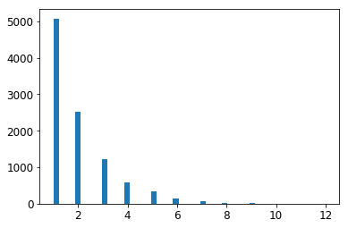

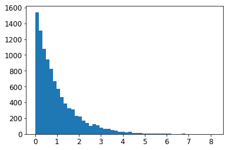

```python
from scipy.stats import geom, expon
geom_distrib=geom(0.5).rvs(10000, random_state=42)
expon_distrib=expon(scale=1).rvs(10000, random_state=42)
plt.hist(geom_distrib, bins=50)
plt.show()
plt.hist(expon_distrib, bins=50)
plt.show()
```